# Wave 1 Income Regressions

Hannah Andrews

1/24/2022

# Create dummies for each factor

# Bivariate and controls individual CAMs

## Acupuncture

### Bivariate

```
##
## Call:
## glm(formula = Acupuncture_W1 ~ LogIncome_W1, family = binomial(link = logit),
##     data = wave1)
##
## Deviance Residuals:
##     Min       1Q   Median       3Q      Max
## -0.1809  -0.1655  -0.1586  -0.1514   3.1638
##
## Coefficients:
##              Estimate Std. Error z value Pr(>|z|)
## (Intercept)   -6.0806     1.4291  -4.255 2.09e-05 ***
## LogIncome_W1   0.1567     0.1296   1.209    0.227
## ---
## Signif. codes:  0 '***' 0.001 '**' 0.01 '*' 0.05 '.' 0.1 ' ' 1
##
## (Dispersion parameter for binomial family taken to be 1)
##
##     Null deviance: 795.43  on 5912  degrees of freedom
## Residual deviance: 793.91  on 5911  degrees of freedom
##   (1195 observations deleted due to missingness)
## AIC: 797.91
##
## Number of Fisher Scoring iterations: 7
```

```
##     LogOdds    pvalue       OR     Lower    Upper
## 1 0.1567179 0.2265145 1.169666 0.9073128 1.507879
```

# Factor dummies

## Mindbody

### Bivariate logistic regression

```
##
## Call:
## glm(formula = mindbody ~ LogIncome_W1, family = binomial(link = logit),
##     data = wave1)
##
## Deviance Residuals:
##     Min       1Q   Median       3Q      Max
## -1.0716  -0.9387  -0.9131   1.4275   1.5010
##
## Coefficients:
##              Estimate Std. Error z value Pr(>|z|)
## (Intercept)   0.21290    0.30464   0.699  0.48465
## LogIncome_W1 -0.07513    0.02799  -2.684  0.00728 **
## ---
## Signif. codes:  0 '***' 0.001 '**' 0.01 '*' 0.05 '.' 0.1 ' ' 1
##
## (Dispersion parameter for binomial family taken to be 1)
##
##     Null deviance: 7642.9  on 5880  degrees of freedom
## Residual deviance: 7635.8  on 5879  degrees of freedom
##   (1227 observations deleted due to missingness)
## AIC: 7639.8
##
## Number of Fisher Scoring iterations: 4
```

```
##       LogOdds      pvalue       OR     Lower     Upper
## 1 -0.07513091 0.007277677 0.927622 0.8780969 0.9799404
```

### Multivariate logistic regression

#### Income and education

```
##
## Call:
## glm(formula = mindbody ~ LogIncome_W1 + Education_W1, family = binomial(link = logit),
##     data = wave1)
##
## Deviance Residuals:
##     Min       1Q   Median       3Q      Max
## -1.4370  -0.9699  -0.8121   1.3311   1.8699
##
## Coefficients:
##                                             Estimate Std. Error z value
## (Intercept)                                  0.73047    0.32234   2.266
## LogIncome_W1                                -0.18137    0.03007  -6.033
## Education_W1HS Diploma/GED                   0.28881    0.11976   2.412
## Education_W1Some College/AA Degree           0.72328    0.11872   6.092
## Education_W1College Grad                     0.96185    0.12634   7.613
## Education_W1Graduate or Professional Degree  0.98888    0.13232   7.474
##                                             Pr(>|z|)
## (Intercept)                                   0.0234 *
## LogIncome_W1                                1.61e-09 ***
## Education_W1HS Diploma/GED                    0.0159 *
## Education_W1Some College/AA Degree          1.11e-09 ***
## Education_W1College Grad                    2.68e-14 ***
## Education_W1Graduate or Professional Degree 7.80e-14 ***
## ---
## Signif. codes:  0 '***' 0.001 '**' 0.01 '*' 0.05 '.' 0.1 ' ' 1
##
## (Dispersion parameter for binomial family taken to be 1)
##
##     Null deviance: 7627.6  on 5868  degrees of freedom
## Residual deviance: 7496.8  on 5863  degrees of freedom
##   (1239 observations deleted due to missingness)
## AIC: 7508.8
##
## Number of Fisher Scoring iterations: 4
```

```
##                                        OR     Lower     Upper
## Income                          0.8341229 0.7863895 0.8847538
## HS diploma or GED               1.3348397 1.0555741 1.6879887
## Some college                    2.0611794 1.6332853 2.6011748
## College grad                    2.6165374 2.0425907 3.3517573
## Graduate or professional degree 2.6882301 2.0741318 3.4841474
```

#### Income, education, and controls

```
##
## Call:
## glm(formula = mindbody ~ LogIncome_W1 + Education_W1 + Race_W1 +
##     Sex_W1 + Marital_W1 + HlthInsurance_W1 + Age_W1, family = binomial(link = logit),
##     data = wave1)
##
## Deviance Residuals:
##     Min       1Q   Median       3Q      Max
## -1.5082  -0.9305  -0.7680   1.2555   2.0290
##
## Coefficients:
##                                              Estimate Std. Error z value
## (Intercept)                                  0.507238   0.387888   1.308
## LogIncome_W1                                -0.145086   0.034832  -4.165
## Education_W1HS Diploma/GED                   0.256319   0.124977   2.051
## Education_W1Some College/AA Degree           0.673251   0.124537   5.406
## Education_W1College Grad                     0.985337   0.133235   7.395
## Education_W1Graduate or Professional Degree  1.054811   0.138577   7.612
## Race_W1Black                                 0.023926   0.133467   0.179
## Race_W1Other                                 0.038709   0.142577   0.271
## Sex_W1Female                                 0.678948   0.058427  11.620
## Marital_W1Married                            0.067978   0.067327   1.010
## HlthInsurance_W1Insured                     -0.192069   0.097566  -1.969
## Age_W1                                      -0.008848   0.002305  -3.839
##                                             Pr(>|z|)
## (Intercept)                                 0.190978
## LogIncome_W1                                3.11e-05 ***
## Education_W1HS Diploma/GED                  0.040274 *
## Education_W1Some College/AA Degree          6.44e-08 ***
## Education_W1College Grad                    1.41e-13 ***
## Education_W1Graduate or Professional Degree 2.70e-14 ***
## Race_W1Black                                0.857732
## Race_W1Other                                0.786008
## Sex_W1Female                                 < 2e-16 ***
## Marital_W1Married                           0.312658
## HlthInsurance_W1Insured                     0.048998 *
## Age_W1                                      0.000124 ***
## ---
## Signif. codes:  0 '***' 0.001 '**' 0.01 '*' 0.05 '.' 0.1 ' ' 1
##
## (Dispersion parameter for binomial family taken to be 1)
##
##     Null deviance: 7443.3  on 5730  degrees of freedom
## Residual deviance: 7157.5  on 5719  degrees of freedom
##   (1377 observations deleted due to missingness)
## AIC: 7181.5
##
## Number of Fisher Scoring iterations: 4
```

```
##                                        OR     Lower     Upper
## Income                          0.8341229 0.7863895 0.8847538
## HS diploma or GED               1.3348397 1.0555741 1.6879887
## Some college                    2.0611794 1.6332853 2.6011748
## College grad                    2.6165374 2.0425907 3.3517573
## Graduate or professional degree 2.6882301 2.0741318 3.4841474
```

```
##                                        OR     Lower     Upper
## Income                          0.8649478 0.8017515 0.9331253
## HS diploma or GED               1.2921648 0.3414958 4.8893422
## Some college                    1.9606017 1.7160333 2.2400260
## College grad                    2.6787144 3.9031795 1.8383759
## Graduate or professional degree 2.8714310 2.9216637 2.8220620
```

### Mindbody summary

Income is significant in the bivariate regression of mindbody practices. Odds ratio is .93, indicating that the odds of using mind body CAM methods decreases by 7% for each one unit increase in logged income.

When education is added to the regression, income remains significant though the odds ratio decreases. The odds ratio is .83, indicating that the odds of using mind body CAM methods decrease by 17% for each one unit increase in logged income. All levels of education are significantly different than having less than a high school education. The odds ratio increases for each level of education.

## Alternative medicines

### Bivariate logistic regression

```
##
## Call:
## glm(formula = altmed ~ LogIncome_W1, family = binomial(link = logit),
##     data = wave1)
##
## Deviance Residuals:
##     Min       1Q   Median       3Q      Max
## -0.4032  -0.3671  -0.3620  -0.3569   2.3777
##
## Coefficients:
##              Estimate Std. Error z value Pr(>|z|)
## (Intercept)  -2.18011    0.58725  -3.712 0.000205 ***
## LogIncome_W1 -0.04644    0.05405  -0.859 0.390255
## ---
## Signif. codes:  0 '***' 0.001 '**' 0.01 '*' 0.05 '.' 0.1 ' ' 1
##
## (Dispersion parameter for binomial family taken to be 1)
##
##     Null deviance: 2795.1  on 5878  degrees of freedom
## Residual deviance: 2794.4  on 5877  degrees of freedom
##   (1229 observations deleted due to missingness)
## AIC: 2798.4
##
## Number of Fisher Scoring iterations: 5
```

```
##       LogOdds    pvalue        OR     Lower    Upper
## 1 -0.04643614 0.3902552 0.9546255 0.8586692 1.061305
```

### Multivariate logistic regression

#### Income and education

```
##
## Call:
## glm(formula = altmed ~ LogIncome_W1 + Education_W1, family = binomial(link = logit),
##     data = wave1)
##
## Deviance Residuals:
##     Min       1Q   Median       3Q      Max
## -0.6194  -0.4018  -0.3437  -0.3079   2.6788
##
## Coefficients:
##                                             Estimate Std. Error z value
## (Intercept)                                 -1.63478    0.61103  -2.675
## LogIncome_W1                                -0.15852    0.05591  -2.835
## Education_W1HS Diploma/GED                   0.33850    0.26678   1.269
## Education_W1Some College/AA Degree           0.59447    0.26305   2.260
## Education_W1College Grad                     1.06615    0.26870   3.968
## Education_W1Graduate or Professional Degree  1.03442    0.27905   3.707
##                                             Pr(>|z|)
## (Intercept)                                  0.00746 **
## LogIncome_W1                                 0.00458 **
## Education_W1HS Diploma/GED                   0.20449
## Education_W1Some College/AA Degree           0.02383 *
## Education_W1College Grad                    7.25e-05 ***
## Education_W1Graduate or Professional Degree  0.00021 ***
## ---
## Signif. codes:  0 '***' 0.001 '**' 0.01 '*' 0.05 '.' 0.1 ' ' 1
##
## (Dispersion parameter for binomial family taken to be 1)
##
##     Null deviance: 2782.8  on 5866  degrees of freedom
## Residual deviance: 2746.0  on 5861  degrees of freedom
##   (1241 observations deleted due to missingness)
## AIC: 2758
##
## Number of Fisher Scoring iterations: 5
```

```
##                                        OR     Lower     Upper
## Income                          0.8534072 0.7648239 0.9522505
## HS diploma or GED               1.4028479 0.8316208 2.3664416
## Some college                    1.8120700 1.0820786 3.0345279
## College grad                    2.9041898 1.7151403 4.9175675
## Graduate or professional degree 2.8134630 1.6282102 4.8615184
```

#### Income, education, and controls

```
##
## Call:
## glm(formula = altmed ~ LogIncome_W1 + Education_W1 + Race_W1 +
##     Sex_W1 + Marital_W1 + HlthInsurance_W1 + Age_W1, family = binomial(link = logit),
##     data = wave1)
##
## Deviance Residuals:
##     Min       1Q   Median       3Q      Max
## -0.8863  -0.4025  -0.3251  -0.2539   2.8767
##
## Coefficients:
##                                              Estimate Std. Error z value
## (Intercept)                                 -3.114197   0.757804  -4.110
## LogIncome_W1                                 0.010809   0.067041   0.161
## Education_W1HS Diploma/GED                   0.335350   0.282255   1.188
## Education_W1Some College/AA Degree           0.523849   0.279537   1.874
## Education_W1College Grad                     1.060726   0.286878   3.697
## Education_W1Graduate or Professional Degree  1.006987   0.295636   3.406
## Race_W1Black                                -0.295299   0.277723  -1.063
## Race_W1Other                                 0.617962   0.215243   2.871
## Sex_W1Female                                 0.750415   0.117850   6.368
## Marital_W1Married                           -0.452906   0.123951  -3.654
## HlthInsurance_W1Insured                     -0.270885   0.173908  -1.558
## Age_W1                                      -0.006027   0.004470  -1.348
##                                             Pr(>|z|)
## (Intercept)                                 3.97e-05 ***
## LogIncome_W1                                0.871910
## Education_W1HS Diploma/GED                  0.234791
## Education_W1Some College/AA Degree          0.060932 .
## Education_W1College Grad                    0.000218 ***
## Education_W1Graduate or Professional Degree 0.000659 ***
## Race_W1Black                                0.287653
## Race_W1Other                                0.004092 **
## Sex_W1Female                                1.92e-10 ***
## Marital_W1Married                           0.000258 ***
## HlthInsurance_W1Insured                     0.119321
## Age_W1                                      0.177593
## ---
## Signif. codes:  0 '***' 0.001 '**' 0.01 '*' 0.05 '.' 0.1 ' ' 1
##
## (Dispersion parameter for binomial family taken to be 1)
##
##     Null deviance: 2716.2  on 5728  degrees of freedom
## Residual deviance: 2604.0  on 5717  degrees of freedom
##   (1379 observations deleted due to missingness)
## AIC: 2628
##
## Number of Fisher Scoring iterations: 6
```

```
##                                        OR     Lower     Upper
## Income                          0.8534072 0.7648239 0.9522505
## HS diploma or GED               1.4028479 0.8316208 2.3664416
## Some college                    1.8120700 1.0820786 3.0345279
## College grad                    2.9041898 1.7151403 4.9175675
## Graduate or professional degree 2.8134630 1.6282102 4.8615184
```

```
##                                       OR     Lower     Upper
## Income                          1.010868 0.3010748 3.3940201
## HS diploma or GED               1.398429 0.3212730 6.0870503
## Some college                    1.688514 4.1022828 0.6949982
## College grad                    2.888469 4.9118971 1.6985802
## Graduate or professional degree 2.737340 2.7698668 2.7051961
```

### Alternative medicines summary

The relationship between income and alternative medicine is not significant in the bivariate analysis.

Income becomes significant when education is included in the model. I’m not sure what this indicates. Did some reading and it seems that some of the variation in residuals for income may have been masked by the variation in education residuals? The odds ratio is .85 indicating that the odds of using alternative medicine decreases by 15% for each one unit increase in logged income.

When controls are included income become insignificant, education becomes less significant though there is still a significant difference between college education and graduate degree vs. having less than a high school diploma.

## Physical and Nutritional approaches

### Bivariate logistic regression

```
##
## Call:
## glm(formula = pna ~ LogIncome_W1, family = binomial(link = logit),
##     data = wave1)
##
## Deviance Residuals:
##     Min       1Q   Median       3Q      Max
## -0.8231  -0.7756  -0.7683   1.6170   1.6707
##
## Coefficients:
##              Estimate Std. Error z value Pr(>|z|)
## (Intercept)  -0.71149    0.33207  -2.143   0.0321 *
## LogIncome_W1 -0.03167    0.03050  -1.038   0.2991
## ---
## Signif. codes:  0 '***' 0.001 '**' 0.01 '*' 0.05 '.' 0.1 ' ' 1
##
## (Dispersion parameter for binomial family taken to be 1)
##
##     Null deviance: 6728.8  on 5889  degrees of freedom
## Residual deviance: 6727.7  on 5888  degrees of freedom
##   (1218 observations deleted due to missingness)
## AIC: 6731.7
##
## Number of Fisher Scoring iterations: 4
```

```
##       LogOdds    pvalue        OR     Lower    Upper
## 1 -0.03167343 0.2990664 0.9688229 0.9126019 1.028507
```

### Multivariate logistic regression

#### Income and education

```
##
## Call:
## glm(formula = pna ~ LogIncome_W1 + Education_W1, family = binomial(link = logit),
##     data = wave1)
##
## Deviance Residuals:
##     Min       1Q   Median       3Q      Max
## -1.0051  -0.8035  -0.7276   1.4970   1.8916
##
## Coefficients:
##                                             Estimate Std. Error z value
## (Intercept)                                 -0.35187    0.34735  -1.013
## LogIncome_W1                                -0.10454    0.03227  -3.240
## Education_W1HS Diploma/GED                   0.20546    0.12988   1.582
## Education_W1Some College/AA Degree           0.49202    0.12860   3.826
## Education_W1College Grad                     0.58177    0.13690   4.250
## Education_W1Graduate or Professional Degree  0.71897    0.14235   5.051
##                                             Pr(>|z|)
## (Intercept)                                  0.31105
## LogIncome_W1                                 0.00120 **
## Education_W1HS Diploma/GED                   0.11367
## Education_W1Some College/AA Degree           0.00013 ***
## Education_W1College Grad                    2.14e-05 ***
## Education_W1Graduate or Professional Degree 4.40e-07 ***
## ---
## Signif. codes:  0 '***' 0.001 '**' 0.01 '*' 0.05 '.' 0.1 ' ' 1
##
## (Dispersion parameter for binomial family taken to be 1)
##
##     Null deviance: 6708.9  on 5877  degrees of freedom
## Residual deviance: 6661.7  on 5872  degrees of freedom
##   (1230 observations deleted due to missingness)
## AIC: 6673.7
##
## Number of Fisher Scoring iterations: 4
```

```
##                                        OR     Lower     Upper
## Income                          0.9007427 0.8455403 0.9595491
## HS diploma or GED               1.2280923 0.9520816 1.5841190
## Some college                    1.6356185 1.2712119 2.1044860
## College grad                    1.7892101 1.3681357 2.3398795
## Graduate or professional degree 2.0523175 1.5526445 2.7127958
```

#### Income, education, and controls

```
##
## Call:
## glm(formula = pna ~ LogIncome_W1 + Education_W1 + Race_W1 + Sex_W1 +
##     Marital_W1 + HlthInsurance_W1 + Age_W1, family = binomial(link = logit),
##     data = wave1)
##
## Deviance Residuals:
##     Min       1Q   Median       3Q      Max
## -1.0961  -0.8053  -0.7170   1.3921   2.0260
##
## Coefficients:
##                                              Estimate Std. Error z value
## (Intercept)                                 -1.331507   0.417763  -3.187
## LogIncome_W1                                -0.046485   0.037211  -1.249
## Education_W1HS Diploma/GED                   0.187669   0.134259   1.398
## Education_W1Some College/AA Degree           0.501712   0.133406   3.761
## Education_W1College Grad                     0.638627   0.142679   4.476
## Education_W1Graduate or Professional Degree  0.739842   0.147417   5.019
## Race_W1Black                                -0.173655   0.148032  -1.173
## Race_W1Other                                 0.150799   0.149307   1.010
## Sex_W1Female                                 0.469882   0.062730   7.491
## Marital_W1Married                           -0.135180   0.071595  -1.888
## HlthInsurance_W1Insured                     -0.014969   0.106807  -0.140
## Age_W1                                       0.004164   0.002457   1.694
##                                             Pr(>|z|)
## (Intercept)                                 0.001436 **
## LogIncome_W1                                0.211576
## Education_W1HS Diploma/GED                  0.162171
## Education_W1Some College/AA Degree          0.000169 ***
## Education_W1College Grad                    7.61e-06 ***
## Education_W1Graduate or Professional Degree 5.20e-07 ***
## Race_W1Black                                0.240759
## Race_W1Other                                0.312499
## Sex_W1Female                                6.86e-14 ***
## Marital_W1Married                           0.059010 .
## HlthInsurance_W1Insured                     0.888540
## Age_W1                                      0.090180 .
## ---
## Signif. codes:  0 '***' 0.001 '**' 0.01 '*' 0.05 '.' 0.1 ' ' 1
##
## (Dispersion parameter for binomial family taken to be 1)
##
##     Null deviance: 6571.6  on 5739  degrees of freedom
## Residual deviance: 6455.4  on 5728  degrees of freedom
##   (1368 observations deleted due to missingness)
## AIC: 6479.4
##
## Number of Fisher Scoring iterations: 4
```

```
##                                        OR     Lower     Upper
## Income                          0.9007427 0.8455403 0.9595491
## HS diploma or GED               1.2280923 0.9520816 1.5841190
## Some college                    1.6356185 1.2712119 2.1044860
## College grad                    1.7892101 1.3681357 2.3398795
## Graduate or professional degree 2.0523175 1.5526445 2.7127958
```

```
##                                        OR     Lower    Upper
## Income                          0.9545788 0.7103112 1.282847
## HS diploma or GED               1.2064339 0.4803217 3.030225
## Some college                    1.6515460 2.1525756 1.267135
## College grad                    1.8938781 1.9502668 1.839120
## Graduate or professional degree 2.0956046 2.0785720 2.112777
```

### Summary for physical and nutrional approaches

In the bivariate analysis income does not significantly predict physical and nutritional approaches.

When education is included logged income becomes significant. The odds ratio is .9 indicating that there is a 10% reduction in the odds of using PNA for each one unit increase in logged income. The difference between having a high school diploma and some college, college grad, and graduate degree are all significant and the odds ratio increases with each level of education.

When controls are included income becomes nonsignificant. Some college, college grad, and graduate degree remain significant.

## Manipulative treatments

### Bivariate logistic regression

```
##
## Call:
## glm(formula = manipulative ~ LogIncome_W1, family = binomial(link = logit),
##     data = wave1)
##
## Deviance Residuals:
##     Min       1Q   Median       3Q      Max
## -0.6431  -0.6251  -0.6161  -0.6013   1.9720
##
## Coefficients:
##              Estimate Std. Error z value Pr(>|z|)
## (Intercept)  -2.09997    0.39586  -5.305 1.13e-07 ***
## LogIncome_W1  0.04989    0.03622   1.378    0.168
## ---
## Signif. codes:  0 '***' 0.001 '**' 0.01 '*' 0.05 '.' 0.1 ' ' 1
##
## (Dispersion parameter for binomial family taken to be 1)
##
##     Null deviance: 5450.2  on 5895  degrees of freedom
## Residual deviance: 5448.3  on 5894  degrees of freedom
##   (1212 observations deleted due to missingness)
## AIC: 5452.3
##
## Number of Fisher Scoring iterations: 4
```

```
##      LogOdds    pvalue       OR    Lower    Upper
## 1 0.04989207 0.1683225 1.051158 0.979129 1.128485
```

### Multivariate logistic regression

#### Income and education

```
##
## Call:
## glm(formula = manipulative ~ LogIncome_W1 + Education_W1, family = binomial(link = logit),
##     data = wave1)
##
## Deviance Residuals:
##     Min       1Q   Median       3Q      Max
## -0.6872  -0.6582  -0.6295  -0.5684   2.0690
##
## Coefficients:
##                                             Estimate Std. Error z value
## (Intercept)                                 -1.86594    0.41354  -4.512
## LogIncome_W1                                -0.01229    0.03806  -0.323
## Education_W1HS Diploma/GED                   0.27575    0.15633   1.764
## Education_W1Some College/AA Degree           0.49761    0.15460   3.219
## Education_W1College Grad                     0.59710    0.16317   3.659
## Education_W1Graduate or Professional Degree  0.62787    0.16977   3.698
##                                             Pr(>|z|)
## (Intercept)                                 6.42e-06 ***
## LogIncome_W1                                0.746797
## Education_W1HS Diploma/GED                  0.077744 .
## Education_W1Some College/AA Degree          0.001288 **
## Education_W1College Grad                    0.000253 ***
## Education_W1Graduate or Professional Degree 0.000217 ***
## ---
## Signif. codes:  0 '***' 0.001 '**' 0.01 '*' 0.05 '.' 0.1 ' ' 1
##
## (Dispersion parameter for binomial family taken to be 1)
##
##     Null deviance: 5436.3  on 5883  degrees of freedom
## Residual deviance: 5410.6  on 5878  degrees of freedom
##   (1224 observations deleted due to missingness)
## AIC: 5422.6
##
## Number of Fisher Scoring iterations: 4
```

```
##                                        OR     Lower    Upper
## Income                          0.9877854 0.9167716 1.064300
## HS diploma or GED               1.3175162 0.9698135 1.789879
## Some college                    1.6447803 1.2148157 2.226924
## College grad                    1.8168429 1.3195525 2.501544
## Graduate or professional degree 1.8736226 1.3432949 2.613322
```

#### Income, education, and controls

```
##
## Call:
## glm(formula = manipulative ~ LogIncome_W1 + Education_W1 + Race_W1 +
##     Sex_W1 + Marital_W1 + HlthInsurance_W1 + Age_W1, family = binomial(link = logit),
##     data = wave1)
##
## Deviance Residuals:
##     Min       1Q   Median       3Q      Max
## -0.7970  -0.6563  -0.6010  -0.5096   2.4468
##
## Coefficients:
##                                              Estimate Std. Error z value
## (Intercept)                                 -2.089837   0.493421  -4.235
## LogIncome_W1                                 0.007652   0.043844   0.175
## Education_W1HS Diploma/GED                   0.205404   0.160083   1.283
## Education_W1Some College/AA Degree           0.424982   0.158872   2.675
## Education_W1College Grad                     0.516656   0.168486   3.066
## Education_W1Graduate or Professional Degree  0.576808   0.173936   3.316
## Race_W1Black                                -0.858440   0.218813  -3.923
## Race_W1Other                                 0.021065   0.172901   0.122
## Sex_W1Female                                 0.243785   0.071480   3.411
## Marital_W1Married                           -0.171884   0.082259  -2.090
## HlthInsurance_W1Insured                      0.259346   0.130840   1.982
## Age_W1                                      -0.003067   0.002833  -1.083
##                                             Pr(>|z|)
## (Intercept)                                 2.28e-05 ***
## LogIncome_W1                                0.861452
## Education_W1HS Diploma/GED                  0.199453
## Education_W1Some College/AA Degree          0.007473 **
## Education_W1College Grad                    0.002166 **
## Education_W1Graduate or Professional Degree 0.000912 ***
## Race_W1Black                                8.74e-05 ***
## Race_W1Other                                0.903033
## Sex_W1Female                                0.000648 ***
## Marital_W1Married                           0.036660 *
## HlthInsurance_W1Insured                     0.047461 *
## Age_W1                                      0.278982
## ---
## Signif. codes:  0 '***' 0.001 '**' 0.01 '*' 0.05 '.' 0.1 ' ' 1
##
## (Dispersion parameter for binomial family taken to be 1)
##
##     Null deviance: 5327.1  on 5744  degrees of freedom
## Residual deviance: 5262.7  on 5733  degrees of freedom
##   (1363 observations deleted due to missingness)
## AIC: 5286.7
##
## Number of Fisher Scoring iterations: 4
```

```
##                                        OR     Lower    Upper
## Income                          0.9877854 0.9167716 1.064300
## HS diploma or GED               1.3175162 0.9698135 1.789879
## Some college                    1.6447803 1.2148157 2.226924
## College grad                    1.8168429 1.3195525 2.501544
## Graduate or professional degree 1.8736226 1.3432949 2.613322
```

```
##                                       OR     Lower    Upper
## Income                          1.007681 0.9669244 1.050156
## HS diploma or GED               1.228022 0.7615385 1.980250
## Some college                    1.529564 2.1422895 1.092086
## College grad                    1.676412 1.0083727 2.787021
## Graduate or professional degree 1.780346 1.7910819 1.769674
```

### Summary for manipulative treatments

Logged income is not a significant predictor of manipulative treatments in the bivariate regression.

Logged income remains nonsignificant when education is included. Education is significant.

Logged income remains nonsignficant when controls are included.

# Dummy count

## Test assumptions for type of regression

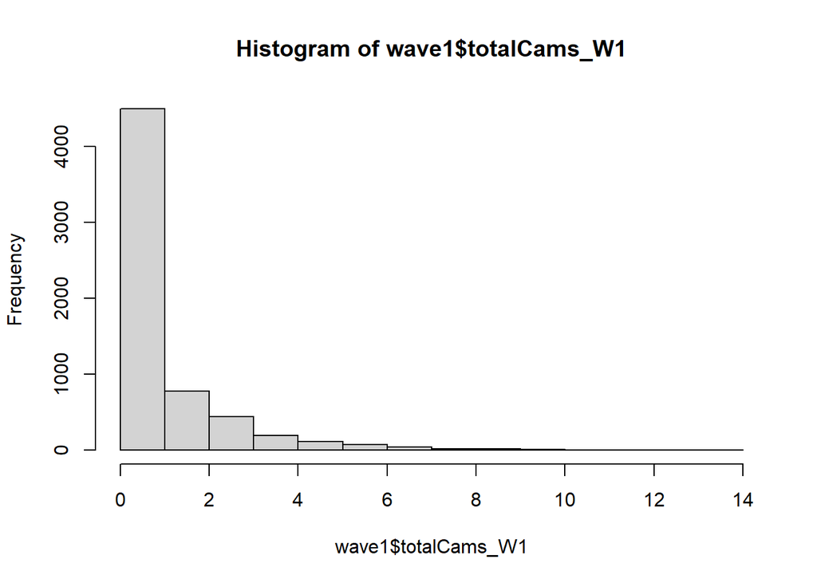

```
## [1] 2.586665
```

```
## [1] 1.117552
```

```
## [1] 1.608311
```

## Negative Binomial Regression - Income

```
##
## Call:
## glm.nb(formula = totalCams_W1 ~ LogIncome_W1, data = wave1, init.theta = 0.8834644154,
##     link = log)
##
## Deviance Residuals:
##     Min       1Q   Median       3Q      Max
## -1.2674  -1.2033  -0.1112   0.4461   3.3412
##
## Coefficients:
##              Estimate Std. Error z value Pr(>|z|)
## (Intercept)   0.47086    0.20878   2.255   0.0241 *
## LogIncome_W1 -0.03239    0.01917  -1.690   0.0911 .
## ---
## Signif. codes:  0 '***' 0.001 '**' 0.01 '*' 0.05 '.' 0.1 ' ' 1
##
## (Dispersion parameter for Negative Binomial(0.8835) family taken to be 1)
##
##     Null deviance: 5766.2  on 5825  degrees of freedom
## Residual deviance: 5763.3  on 5824  degrees of freedom
##   (1282 observations deleted due to missingness)
## AIC: 17129
##
## Number of Fisher Scoring iterations: 1
##
##
##               Theta:  0.8835
##           Std. Err.:  0.0360
##
##  2 x log-likelihood:  -17122.6550
```

## Income and Education

```
##
## Call:
## glm.nb(formula = totalCams_W1 ~ LogIncome_W1 + Education_W1,
##     data = wave1, init.theta = 0.9490508013, link = log)
##
## Deviance Residuals:
##     Min       1Q   Median       3Q      Max
## -1.5247  -1.1994  -0.2814   0.3100   3.0492
##
## Coefficients:
##                                             Estimate Std. Error z value
## (Intercept)                                  0.77645    0.21458   3.618
## LogIncome_W1                                -0.10914    0.01990  -5.484
## Education_W1HS Diploma/GED                   0.27833    0.08077   3.446
## Education_W1Some College/AA Degree           0.55419    0.08006   6.922
## Education_W1College Grad                     0.72645    0.08476   8.571
## Education_W1Graduate or Professional Degree  0.82797    0.08826   9.381
##                                             Pr(>|z|)
## (Intercept)                                 0.000296 ***
## LogIncome_W1                                4.16e-08 ***
## Education_W1HS Diploma/GED                  0.000569 ***
## Education_W1Some College/AA Degree          4.46e-12 ***
## Education_W1College Grad                     < 2e-16 ***
## Education_W1Graduate or Professional Degree  < 2e-16 ***
## ---
## Signif. codes:  0 '***' 0.001 '**' 0.01 '*' 0.05 '.' 0.1 ' ' 1
##
## (Dispersion parameter for Negative Binomial(0.9491) family taken to be 1)
##
##     Null deviance: 5925.9  on 5813  degrees of freedom
## Residual deviance: 5767.5  on 5808  degrees of freedom
##   (1294 observations deleted due to missingness)
## AIC: 16943
##
## Number of Fisher Scoring iterations: 1
##
##
##               Theta:  0.9491
##           Std. Err.:  0.0399
##
##  2 x log-likelihood:  -16929.3380
```

## Compare with and without income

```
## Likelihood ratio tests of Negative Binomial Models
##
## Response: totalCams_W1
##                         Model     theta Resid. df    2 x log-lik.   Test    df
## 1                LogIncome_W1 0.8834644      5824       -17122.65
## 2 LogIncome_W1 + Education_W1 0.9490508      5808       -16929.34 1 vs 2    16
##   LR stat. Pr(Chi)
## 1
## 2 193.3166       0
```

## Negative Binomial Regression with Controls

```
##
## Call:
## glm.nb(formula = totalCams_W1 ~ LogIncome_W1 + Education_W1 +
##     Race_W1 + Sex_W1 + Marital_W1 + HlthInsurance_W1 + Age_W1,
##     data = wave1, init.theta = 1.029688557, link = log)
##
## Deviance Residuals:
##     Min       1Q   Median       3Q      Max
## -1.6504  -1.1777  -0.3945   0.3379   3.5430
##
## Coefficients:
##                                              Estimate Std. Error z value
## (Intercept)                                  0.179067   0.252690   0.709
## LogIncome_W1                                -0.045203   0.022568  -2.003
## Education_W1HS Diploma/GED                   0.244189   0.082240   2.969
## Education_W1Some College/AA Degree           0.500867   0.081830   6.121
## Education_W1College Grad                     0.716214   0.086921   8.240
## Education_W1Graduate or Professional Degree  0.810752   0.089842   9.024
## Race_W1Black                                -0.269159   0.091753  -2.934
## Race_W1Other                                 0.180788   0.088976   2.032
## Sex_W1Female                                 0.426463   0.037714  11.308
## Marital_W1Married                           -0.151330   0.043095  -3.512
## HlthInsurance_W1Insured                     -0.104427   0.063030  -1.657
## Age_W1                                      -0.002452   0.001488  -1.648
##                                             Pr(>|z|)
## (Intercept)                                 0.478548
## LogIncome_W1                                0.045183 *
## Education_W1HS Diploma/GED                  0.002986 **
## Education_W1Some College/AA Degree          9.31e-10 ***
## Education_W1College Grad                     < 2e-16 ***
## Education_W1Graduate or Professional Degree  < 2e-16 ***
## Race_W1Black                                0.003351 **
## Race_W1Other                                0.042166 *
## Sex_W1Female                                 < 2e-16 ***
## Marital_W1Married                           0.000445 ***
## HlthInsurance_W1Insured                     0.097565 .
## Age_W1                                      0.099346 .
## ---
## Signif. codes:  0 '***' 0.001 '**' 0.01 '*' 0.05 '.' 0.1 ' ' 1
##
## (Dispersion parameter for Negative Binomial(1.0297) family taken to be 1)
##
##     Null deviance: 5982.2  on 5677  degrees of freedom
## Residual deviance: 5651.6  on 5666  degrees of freedom
##   (1430 observations deleted due to missingness)
## AIC: 16399
##
## Number of Fisher Scoring iterations: 1
##
##
##               Theta:  1.0297
##           Std. Err.:  0.0455
##
##  2 x log-likelihood:  -16373.2000
```

## Comparing to Poisson model

```
## 'log Lik.' 0 (df=13)
```

## Converting coefficients

```
##                                                 Estimate        2.5 %
## (Intercept)                                  0.179066566 -0.308348179
## LogIncome_W1                                -0.045203069 -0.088728706
## Education_W1HS Diploma/GED                   0.244189451  0.082960185
## Education_W1Some College/AA Degree           0.500866824  0.340509706
## Education_W1College Grad                     0.716214405  0.546037339
## Education_W1Graduate or Professional Degree  0.810751529  0.635417740
## Race_W1Black                                -0.269158630 -0.448912098
## Race_W1Other                                 0.180787553  0.006201449
## Sex_W1Female                                 0.426463247  0.352636764
## Marital_W1Married                           -0.151330155 -0.235844367
## HlthInsurance_W1Insured                     -0.104426771 -0.228381440
## Age_W1                                      -0.002452175 -0.005465485
##                                                    97.5 %
## (Intercept)                                  0.6668797073
## LogIncome_W1                                -0.0017505839
## Education_W1HS Diploma/GED                   0.4064033907
## Education_W1Some College/AA Degree           0.6622751625
## Education_W1College Grad                     0.8874497173
## Education_W1Graduate or Professional Degree  0.9871460588
## Race_W1Black                                -0.0898557986
## Race_W1Other                                 0.3566817668
## Sex_W1Female                                 0.5003961475
## Marital_W1Married                           -0.0668730167
## HlthInsurance_W1Insured                      0.0192281232
## Age_W1                                       0.0005607285
```

```
##                                              Estimate     2.5 %    97.5 %
## (Intercept)                                 1.1961004 0.7346595 1.9481490
## LogIncome_W1                                0.9558034 0.9150938 0.9982509
## Education_W1HS Diploma/GED                  1.2765862 1.0864985 1.5014081
## Education_W1Some College/AA Degree          1.6501510 1.4056639 1.9391993
## Education_W1College Grad                    2.0466707 1.7263983 2.4289273
## Education_W1Graduate or Professional Degree 2.2495980 1.8878106 2.6835648
## Race_W1Black                                0.7640220 0.6383222 0.9140630
## Race_W1Other                                1.1981606 1.0062207 1.4285812
## Sex_W1Female                                1.5318302 1.4228142 1.6493745
## Marital_W1Married                           0.8595639 0.7899036 0.9353140
## HlthInsurance_W1Insured                     0.9008408 0.7958206 1.0194142
## Age_W1                                      0.9975508 0.9945494 1.0005609
```

When including controls, the percent change in the incident rate for total CAMs is a 4% decrease for every one unit increase in logged income. Incidence rate increases with each additional unit of education compared to the reference group (less than a high school diploma).